# Analysis of Factors Influencing Philippine Family Population Based on GLM

Author

Group_03

# Introduction

In Philippine, **FIES**(Family Income and Expenditure Survey), which is undertaken every three years, is aimed at providing data on family income and expenditure. This dataset, comes from the FIES recorded in the Philippines, is analysed in this report.

In particular, this report presents numerical and graphical summaries of FIES and fits a **Generalized Linear Model(GLM)** with **Poisson Regression** to analyze which household related variables influence the number of people living in a household.

# Research Question

Which household related variables influence the number of people living in a household?

# Data Cleaning

First read the data and tidy the data using tidyverse:

```r
# Read the data set
Data_FIES <- read.csv("dataset03.csv")
# Tidy the data
FIES <- Data_FIES %>%
  # Place the dependent variable in the first column and delete the unique value
  select(Total.Number.of.Family.members, everything(), -Region) %>%
  # Convert categorical variables into factors
  mutate(
    Household.Head.Sex = as.factor(Household.Head.Sex),
    Type.of.Household = as.factor(Type.of.Household),
    Electricity = as.factor(Electricity)) %>%
  # Remove Missing Values
  drop_na()
FIES_saved <- FIES # Used for model fitting
```

The dependent variable and independent variables are shown as below:

**Dependent Variable**:

- **Total.Number.of.Family.members**: Number of people living in the house.

**Independent Variables**:

- **Total.Household.Income**: Annual household income (in Philippine peso)
- **Total.Food.Expenditure**: Annual expenditure by the household on food (in Philippine peso)
- **Household.Head.Sex**: Head of the households sex
- **Household.Head.Age**: Head of the households age (in years)
- **Type.of.Household**: Relationship between the group of people living in the house
- **House.Floor.Area**: Floor area of the house (in $m^2$)
- **House.Age**: Age of the building (in years)
- **Number.of.bedrooms**: Number of bedrooms in the house
- **Electricity**: Does the house have electricity? (1=Yes, 0=No)

# Exploratory Data Analysis

Then we can check the data structure and get summary statistics of all variables:

```r
str(FIES) # Check data structure
```

```
'data.frame':   1887 obs. of  10 variables:
 $ Total.Number.of.Family.members: int  10 8 5 6 6 5 5 5 8 2 ...
 $ Total.Household.Income        : int  89359 108400 51982 76623 135232 73522 60369 60146 103365 53395 ...
 $ Total.Food.Expenditure        : int  54537 56611 30827 43639 59614 47563 48962 47482 55666 18361 ...
 $ Household.Head.Sex            : Factor w/ 2 levels "Female","Male": 1 2 2 2 2 2 1 2 2 2 ...
 $ Household.Head.Age            : int  34 55 26 53 55 38 50 32 49 60 ...
 $ Type.of.Household             : Factor w/ 3 levels "Extended Family",..: 2 2 2 2 2 2 2 2 2 2 ...
 $ House.Floor.Area              : int  64 60 48 42 56 56 48 42 48 20 ...
 $ House.Age                     : int  11 13 13 5 5 8 5 13 3 19 ...
 $ Number.of.bedrooms            : int  1 3 1 2 2 1 1 1 2 1 ...
 $ Electricity                   : Factor w/ 2 levels "0","1": 1 2 1 1 2 2 1 1 1 2 ...
```

```r
summary(FIES) # Get summary statistics of all variables
```

```
 Total.Number.of.Family.members Total.Household.Income Total.Food.Expenditure
 Min.   : 1.000                 Min.   :  16238        Min.   :  3704
 1st Qu.: 3.000                 1st Qu.:  85545        1st Qu.: 38311
 Median : 4.000                 Median : 131806        Median : 54594
 Mean   : 4.677                 Mean   : 214058        Mean   : 64113
 3rd Qu.: 6.000                 3rd Qu.: 249176        3rd Qu.: 77068
 Max.   :16.000                 Max.   :2598050        Max.   :363572
 Household.Head.Sex Household.Head.Age
 Female: 400        Min.   :15.00
 Male  :1487        1st Qu.:41.00
                    Median :51.00
                    Mean   :51.52
                    3rd Qu.:61.00
                    Max.   :95.00
                              Type.of.Household House.Floor.Area   House.Age
 Extended Family                       : 567    Min.   : 10.00   Min.   : 0.0
 Single Family                         :1311    1st Qu.: 30.00   1st Qu.:10.0
 Two or More Nonrelated Persons/Members:   9    Median : 50.00   Median :16.0
                                                Mean   : 59.81   Mean   :19.5
                                                3rd Qu.: 80.00   3rd Qu.:26.0
                                                Max.   :600.00   Max.   :95.0
 Number.of.bedrooms Electricity
 Min.   :0.000      0: 257
 1st Qu.:1.000      1:1630
 Median :2.000
 Mean   :1.945
 3rd Qu.:2.000
 Max.   :8.000
```

```r
dim(FIES) # Check dataset dimensions (number of rows and columns)
```

```
[1] 1887   10
```

## Numerical summaries and Data visualization

Now we can take a look at the numerical summaries and data visualization of **dependent variable** shown in the following tables and plots:

Table 1: Summary statistics for ‘Total.Number.of.Family.members’

| Mean | Median | Std. Dev | Minimum | Maximum | Interquartile Range | Sample Size |
| --- | --- | --- | --- | --- | --- | --- |
| 4.68 | 4.00 | 2.30 | 1.00 | 16.00 | 3.00 | 1,887.00 |

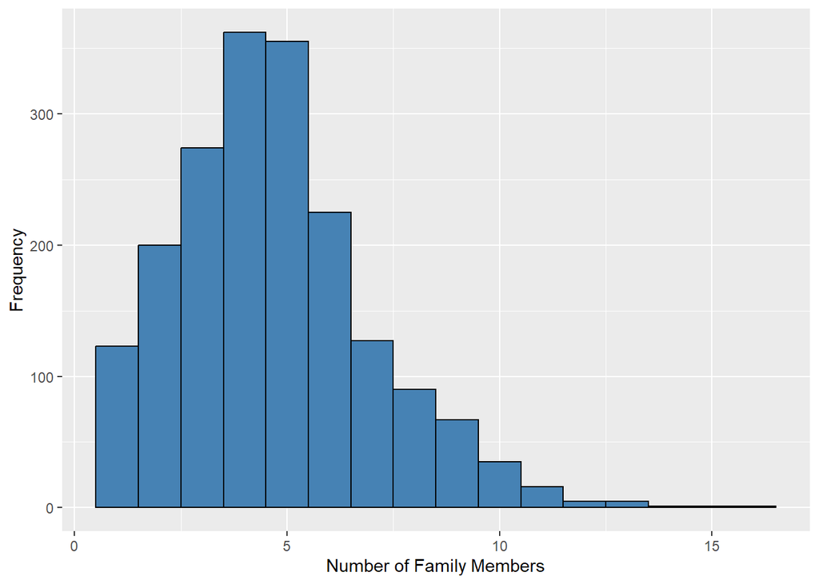

Figure 1: Histogram of ‘Total.Number.of.Family.members’

From Table 1, we can see our dataset includes 1887 samples, which is a sufficiently large sample size to ensure reliability. The mean value (4.68) and median (4.00) are very close, suggesting a roughly symmetric distribution. However, the median is slightly lower than the mean hints at a mild right skew in the data. The standard deviation (2.30) indicates moderate variability around the mean.

Then check the variance of the dependent variable and compare with the mean:

```
mean = 4.677266
```

```
var = 5.28232
```

```
var_ratio = 1.129361
```

var/mean=5.28/4.68=1.13 indicates that there is no overdispersion problem, so Poisson regression model may be appropriate.

Then we separate independent variables into categorical variables and numerical variables for analysis.

1. **Categorical Variables**

Table 2: Summary statistics on ‘Total.Number.of.Family.members’ by ‘Household.Head.Sex’

| Household.Head.Sex | Family Size Summary Mean | Family Size Summary Median | Family Size Summary Std. Dev | Family Size Summary Min | Family Size Summary Max | Family Size Summary IQR | Family Size Summary Sample |
| --- | --- | --- | --- | --- | --- | --- | --- |
| Female | 3.83 | 3.00 | 2.33 | 1.00 | 15.00 | 3.00 | 400.00 |
| Male | 4.91 | 5.00 | 2.23 | 1.00 | 16.00 | 3.00 | 1,487.00 |

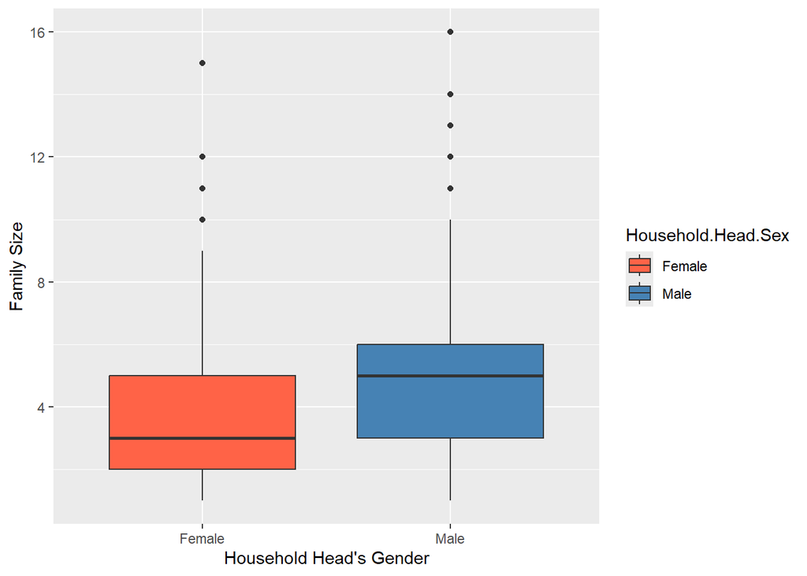

Figure 2: Boxplot of ‘Total.Number.of.Family.members’ by ‘Household.Head.Sex’

Table 2 compares the ‘Total.Number.of.Family.members’ between female-headed and male-headed households. Female-headed households exhibit smaller family size, with a mean of 3.83 and a median of 3.00, while male-headed households show significantly larger families (mean = 4.91, median = 5.00). Despite similar variability in both groups (standard deviations of nearly 2.3), the male-headed households display a broader range. Notably, the dataset is heavily skewed toward male-headed households (1487 samples vs. 400 female samples), which could influence the result. Both groups share identical interquartile ranges (IQR = 3.00), suggesting comparable central clustering of data.

Table 3: Summary statistics on ‘Total.Number.of.Family.members’ by ‘Type.of.Household’

| Type.of.Household | Household Summary Mean | Household Summary Median | Household Summary Std. Dev | Household Summary Min | Household Summary Max | Household Summary IQR | Household Summary Sample Size |
| --- | --- | --- | --- | --- | --- | --- | --- |
| Single Family | 4.14 | 4.00 | 2.03 | 1.00 | 13.00 | 2.00 | 1,311.00 |
| Extended Family | 5.88 | 5.00 | 2.40 | 2.00 | 16.00 | 3.00 | 567.00 |
| Two or More Nonrelated Persons/Members | 6.89 | 6.00 | 2.80 | 4.00 | 12.00 | 2.00 | 9.00 |

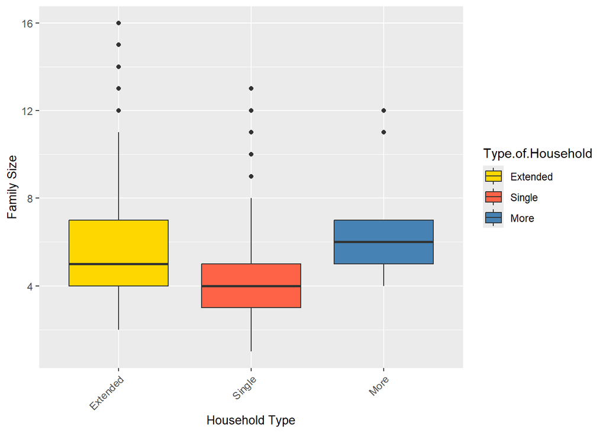

Figure 3: Boxplot of ‘Total.Number.of.Family.members’ by ‘Type.of.Household’

Table 3 summarizes family size statistics across three household types. Single-family households have the smallest average family size (mean = 4.14, median = 4.00) with a large sample size (1311). Extended families show significantly larger family sizes (mean=5.88, median = 5.00) and a broader spread (max = 16). Households with two or more unrelated members report the highest average (mean = 6.89, median - 6.00), but with a extremely small sample size (9) weakens reliability.

Table 4: Summary statistics on ‘Total.Number.of.Family.members’ by ‘Electricity’

| Electricity | Mean | Median | Std | Min | Max | IQ | Sample |
| --- | --- | --- | --- | --- | --- | --- | --- |
| 0 | 4.70 | 5.00 | 2.47 | 1.00 | 12.00 | 3.00 | 257.00 |
| 1 | 4.67 | 4.00 | 2.27 | 1.00 | 16.00 | 3.00 | 1,630.00 |

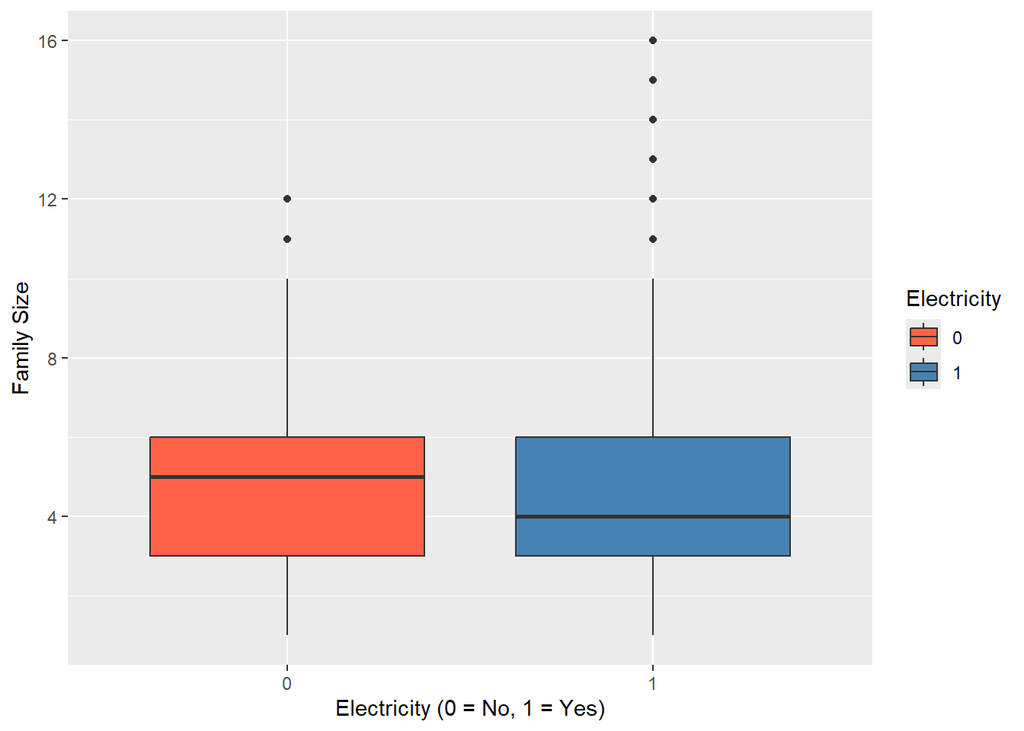

Figure 4: Boxplot of ‘Total.Number.of.Family.members’ by ‘Electricity’

From Table 4, we can see households with electricity (1,630) are about six times more than those without (257). The mean values are nearly identical (4.70 vs. 4.67), but the median is slightly higher for households without electricity (5.00 vs. 4.00). The standard deviation is also slightly larger in the non-electric group (2.47 vs. 2.27), indicating a bit more variability. The maximum value is higher in the electricity group (16.00 vs. 12.00), suggesting a wider range. Both groups have the same interquartile range (3.00), meaning their middle 50% distributions are similar. These differences can be visualized more clearly with boxplots.

Figure 4 shows that households without electricity tend to have a slightly larger median family size compared to those with electricity. However, the distributions of family sizes in both groups are quite similar. The spread of family sizes in both groups is also comparable, as indicated by the interquartile range. Additionally, both groups exhibit several outliers, representing families with unusually large sizes, as shown by the points beyond the “whiskers” of the boxplots.

2. **Numerical Variables**

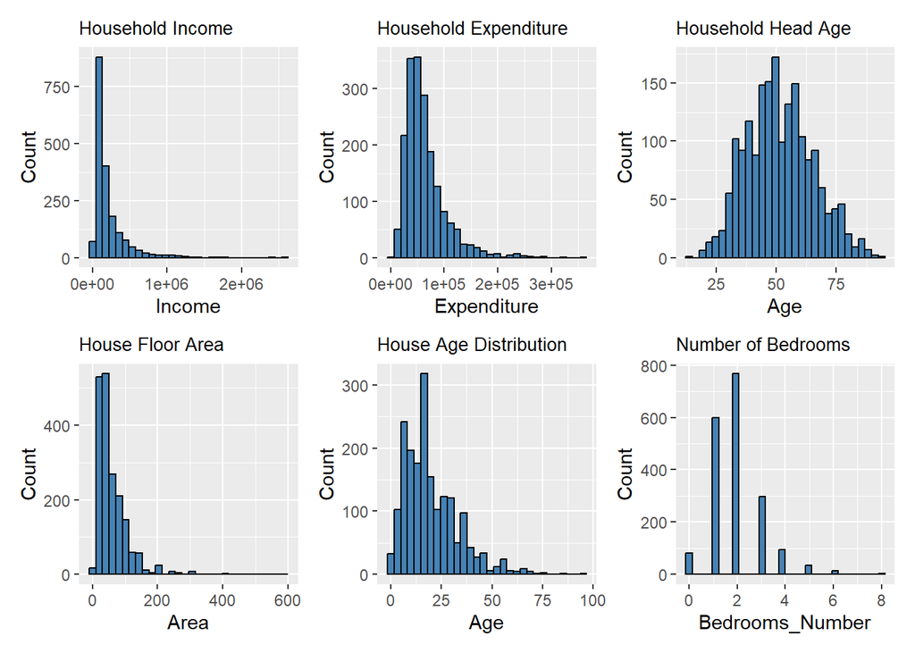

Figure 5: Histograms for Numerical Variables

From Figure 5, we can see the distributions of ‘Total.Household.Income’, ‘Total.Food.Expenditure’, and ‘House.Floor.Area’ are right-skewed, so applying a log transformation would be beneficial when fitting a Poisson model.

“Household.Head.Age” follows an approximately normal distribution, with most household heads falling within the 30-60 age range. This suggests that middle-aged individuals are the primary decision-makers in households.

The distribution of ‘House.Floor.Area’ is strongly right-skewed, with most houses having relatively small areas, while a few have significantly larger ones. The scarcity of large houses may be due to their higher costs.

The distribution of ‘House.Age’ exhibits a slight bimodal pattern, indicating the presence of two types of houses: newly houses and older houses.

```r
# Convert 'Number.of.bedrooms' to categorical variable
FIES$Bedroom.Category <- cut(FIES$Number.of.bedrooms,
         c(-1, 1, 3, Inf),
         labels = c("Small", "Medium", "Large"),right = TRUE)
# Convert categorical variable into factor
FIES$Bedroom.Category <- factor(FIES$Bedroom.Category)
```

Then we can use the heat map to check the correlation between numerical variables and dependent variable:

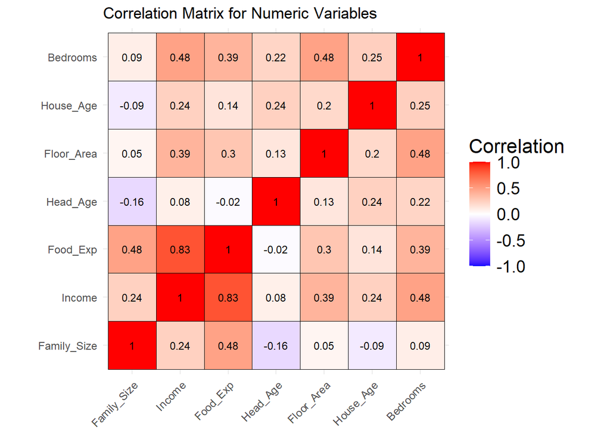

Figure 6: Heat map for numerical variables by ‘Total.Number.of.Family.members’

From Figure 6, we can see there is a strong correlation between ‘Total.Household.Income’ and ‘Total.Food.Expenditure’. We will address this issue in the subsequent modeling process. ‘Total.Number.of.Family.Members’ shows a strong correlation with ‘Total.Food.Expenditure’, while ‘Household.Head.Age’ and ‘House.Age’ have a slight negative correlation with ‘Total.Number.of.Family.Members’. There is also some correlation between ‘Total.Household.Income’ and ‘Number.of.bedrooms’, ‘Total.Household.Income’ and ‘House.Floor.Area’, ‘Total.Food.Expenditure’ and ‘Number.of.bedrooms’, and ‘House.Floor.Area’ and ‘Number.of.bedrooms’.

# Formal Data Analysis

Since the dependent variable ‘Total.Number.of.Family.members’ is a typical count variable with a mean and variance that are approximately equal, Poisson regression was chosen for modeling. Based on the results of EDA, some variables were log-transformed to improve linear relationships and reduce heteroscedasticity. All selected variables were then included in the model, and stepwise regression using drop1(poisson_model, test = “F”) was performed to assess variable significance, gradually eliminating insignificant variables to ensure the final model’s robustness and explanatory power.

Fit the first Poisson regression model:

$$y_{FS} = \beta_0 + \beta_1 \log[f_{In}(x)] + \beta_2 \log[f_{FE}(x)] + \beta_3 [f_{HS}(x)] + \beta_4 [f_{HeA}(x)] + \beta_5 [f_{HT}(x)] + \beta_6 \log[f_{FA}(x)] + \beta_7 \log[f_{HoA}(x)] + \beta_8 [f_{Bed}(x)] + \beta_9 [f_{El}(x)]$$

where

```r
poisson_model1 <- glm(Family_Size ~
                       log(Income) +
                       log(Food_Exp) +
                       Head_Sex +
                       Head_Age +
                       Household_Type +
                       log(Floor_Area) +
                       log(House_Age+0.1) +
                       Bedrooms +
                       Electricity,
                     family = poisson(link = "log"),
                     data = FIES)
```

```
Single term deletions

Model:
Family_Size ~ log(Income) + log(Food_Exp) + Head_Sex + Head_Age +
    Household_Type + log(Floor_Area) + log(House_Age + 0.1) +
    Bedrooms + Electricity
                     Df Deviance    AIC  F value    Pr(>F)
<none>                    1218.5 7450.3
log(Income)           1   1315.2 7545.0 148.8405 < 2.2e-16 ***
log(Food_Exp)         1   1588.8 7818.6 570.1446 < 2.2e-16 ***
Head_Sex              1   1244.6 7474.4  40.1738 2.903e-10 ***
Head_Age              1   1241.2 7471.0  34.9168 4.077e-09 ***
Household_Type        2   1362.3 7590.1 110.6954 < 2.2e-16 ***
log(Floor_Area)       1   1218.7 7448.4   0.2034    0.6520
log(House_Age + 0.1)  1   1228.7 7458.5  15.6560 7.880e-05 ***
Bedrooms              1   1218.5 7448.3   0.0287    0.8654
Electricity           1   1229.0 7458.7  16.1106 6.210e-05 ***
---
Signif. codes:  0 '***' 0.001 '**' 0.01 '*' 0.05 '.' 0.1 ' ' 1
```

```r
FIES$Bedroom.Category <- cut(FIES$Bedrooms,
                             breaks = c(-1, 1, 3, Inf),
                             labels = c("Small", "Medium", "Large"),
                             right = TRUE)
FIES$Bedroom.Category <- factor(FIES$Bedroom.Category)
```

```r
model_cat <- lm(Family_Size ~ Bedroom.Category, data = FIES)
```

```r
model_summary <- summary(model_cat)$coefficients
library(knitr)
kable(model_summary, caption = "Model Coefficients and Significance", format = "latex")
```

[output not shown]

Then we can fit a Poisson regression model with ‘Bedroom.Category’ the same as above:

```r
poisson_model_cat <- glm(Family_Size ~
                       log(Income) +
                       log(Food_Exp) +
                       Head_Sex +
                       Head_Age +
                       Household_Type +
                       log(House_Age+1) +
                       Bedroom.Category +
                       Electricity,
                     family = poisson(link = "log"),
                     data = FIES)
```

```
Single term deletions

Model:
Family_Size ~ log(Income) + log(Food_Exp) + Head_Sex + Head_Age +
    Household_Type + log(House_Age + 1) + Bedroom.Category +
    Electricity
                   Df Deviance    AIC  F value    Pr(>F)
<none>                  1216.0 7447.8
log(Income)         1   1314.7 7544.4 152.1694 < 2.2e-16 ***
log(Food_Exp)       1   1584.2 7814.0 567.9627 < 2.2e-16 ***
Head_Sex            1   1241.2 7471.0  38.8521 5.632e-10 ***
Head_Age            1   1239.4 7469.1  35.9972 2.366e-09 ***
Household_Type      2   1359.7 7587.5 110.8329 < 2.2e-16 ***
log(House_Age + 1)  1   1226.6 7456.3  16.2519 5.767e-05 ***
Bedroom.Category    2   1218.5 7446.2   1.8675    0.1548
Electricity         1   1227.7 7457.4  17.9213 2.414e-05 ***
---
Signif. codes:  0 '***' 0.001 '**' 0.01 '*' 0.05 '.' 0.1 ' ' 1
```

After converting ‘Bedrooms’ into a categorical variable and refitting the model, it remained insignificant, so it was ultimately removed.

Fit the second Poisson regression model:

$$y_{FS} = \beta_0 + \beta_1 \log[f_{In}(x)] + \beta_2 \log[f_{FE}(x)] + \beta_3 [f_{HS}(x)] + \beta_4 [f_{HeA}(x)] + \beta_5 [f_{HT}(x)] + \beta_6 \log[f_{HoA}(x)] + \beta_8 [f_{El}(x)]$$

```r
poisson_model2 <- glm(Family_Size ~
                          log(Income) +
                          log(Food_Exp) +
                          Head_Sex +
                          Head_Age +
                          Household_Type +
                          log(House_Age+1) +
                          Electricity,
                        family = poisson(link = "log"),
                        data = FIES)
```

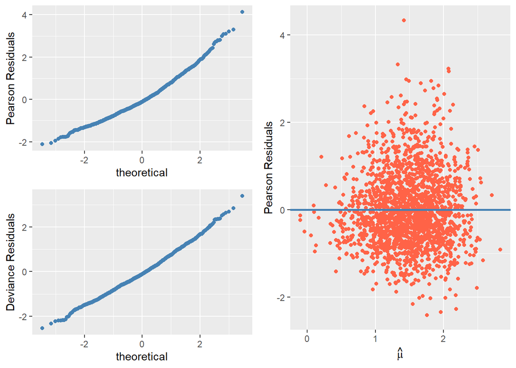

Figure 7: The Pearson and deviance residuals against the linear predictor

By plotting the QQ plots of Pearson and Deviance, we found that the data conform to the normality assumption. To further assess whether there is significant overdispersion in the Deviance distribution, we compared the performance of the original Poisson model and the Quasi-Poisson model in handling overdispersion. By comparing the standardized Pearson residuals of both models, we found that the original Poisson model performed better, indicating no significant overdispersion. Therefore, no adjustment was made to the standard errors of the parameters, as overdispersion was not evident.

```
Call:
glm(formula = Family_Size ~ log(Income) + log(Food_Exp) + Head_Sex +
    Head_Age + Household_Type + log(House_Age + 1) + Electricity,
    family = poisson(link = "log"), data = FIES)

Coefficients:
                                                       Estimate Std. Error
(Intercept)                                          -2.7453484  0.1956354
log(Income)                                          -0.2731779  0.0218092
log(Food_Exp)                                         0.7355788  0.0313499
Head_SexMale                                          0.1454000  0.0235193
Head_Age                                             -0.0041994  0.0007119
Household_TypeSingle Family                          -0.2847395  0.0193537
Household_TypeTwo or More Nonrelated Persons/Members  0.0961818  0.1043781
log(House_Age + 1)                                   -0.0512741  0.0128593
Electricity1                                         -0.1092392  0.0271865
                                                     z value Pr(>|z|)
(Intercept)                                          -14.033  < 2e-16 ***
log(Income)                                          -12.526  < 2e-16 ***
log(Food_Exp)                                         23.464  < 2e-16 ***
Head_SexMale                                           6.182 6.32e-10 ***
Head_Age                                              -5.899 3.66e-09 ***
Household_TypeSingle Family                          -14.712  < 2e-16 ***
Household_TypeTwo or More Nonrelated Persons/Members   0.921    0.357
log(House_Age + 1)                                    -3.987 6.68e-05 ***
Electricity1                                          -4.018 5.87e-05 ***
---
Signif. codes:  0 '***' 0.001 '**' 0.01 '*' 0.05 '.' 0.1 ' ' 1

(Dispersion parameter for poisson family taken to be 0.6580882)

    Null deviance: 2130.1  on 1886  degrees of freedom
Residual deviance: 1218.5  on 1878  degrees of freedom
AIC: 7446.2

Number of Fisher Scoring iterations: 4
```

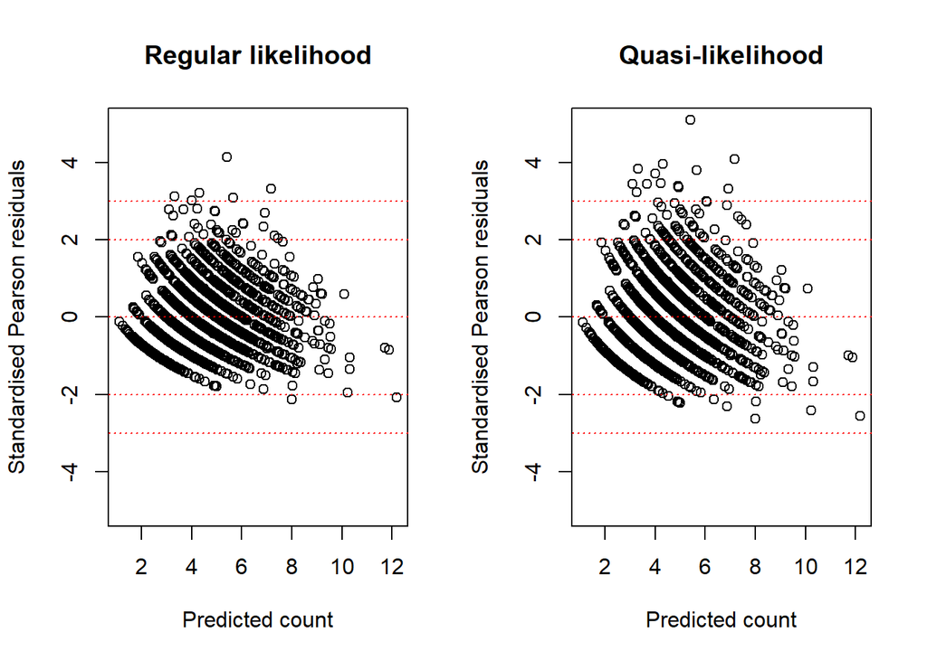

Figure 8: Regular likelihood and Quasi-likelihood

Based on the model comparison and LRT test results, and considering the high correlation observed in the EDA heatmap, an interaction term between ‘Income’ and ‘Food_Exp’ was introduced. After comparing the original model with the model including the interaction term, it was found that the Deviance decreased by 47.118 after adding the interaction term, indicating that the inclusion of the interaction term significantly improved the model’s fit. Therefore, the conclusion can be made that introducing the interaction term effectively enhanced the model’s explanatory power and fit the final Poisson regression model:

$$y_{FS} = \beta_0 + \beta_1 \log[f_{In}(x)] + \beta_2 \log[f_{FE}(x)] + \beta_3 \log[f_{In}(x)]\log[f_{FE}(x)] + \beta_4 [f_{HS}(x)] + \beta_5 [f_{HeA}(x)] + \beta_6 [f_{HT}(x)] + \beta_7 \log[f_{HoA}(x)] + \beta_8 [f_{El}(x)]$$

where

- $y_{FS}$: The expected value of family size (dependent variable).
- $\log[f_{In}(x)]$: The logarithm of household income, measuring the economic level of the family.
- $\log[f_{FE}(x)]$: The logarithm of food expenditure, representing the household’s spending on food.
- $\log[f_{In}(x)]\log[f_{FE}(x)]$: The interaction term between income and food expenditure, measuring their joint effect on family size.
- $f_{HS}(x)$: The gender of the household head (categorical variable, usually 0 for female and 1 for male).
- $f_{HeA}(x)$: The age of the household head (continuous variable), indicating the effect of the household head’s age on family size.
- $f_{HT}(x)$: The type of household (categorical variable), indicating different family structures such as single-parent or nuclear families.
- $\log[f_{HoA}(x)]$: The logarithm of house age (with +1 to avoid taking the logarithm of 0), measuring the age of the dwelling.
- $f_{EL}(x)$: Whether the household has access to electricity (0 = no, 1 = yes), reflecting the household’s infrastructure.

```r
poisson_model4 <- glm(Family_Size ~
                      log(Income) * log(Food_Exp) +
                      Head_Sex +
                      Head_Age +
                      Household_Type +
                      log(House_Age + 1) +
                      Electricity,
                      family = poisson(link = "log"),
                      data = FIES)
```

```
Analysis of Deviance Table

Model 1: Family_Size ~ log(Income) + log(Food_Exp) + Head_Sex + Head_Age +
    Household_Type + log(House_Age + 1) + Electricity
Model 2: Family_Size ~ log(Income) * log(Food_Exp) + Head_Sex + Head_Age +
    Household_Type + log(House_Age + 1) + Electricity
  Resid. Df Resid. Dev Df Deviance  Pr(>Chi)
1      1878     1218.5
2      1877     1171.3  1   47.118 6.685e-12 ***
---
Signif. codes:  0 '***' 0.001 '**' 0.01 '*' 0.05 '.' 0.1 ' ' 1
```

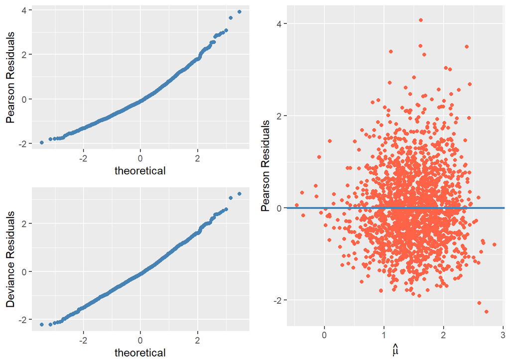

Figure 9: The Pearson and deviance residuals against the linear predictor

The QQ plots of the Pearson and Deviance both conform to the normality assumption and there is no obvious overdispersion in the Residuals plot.

# Conclusion

From the results, we can see:

In conclusion, these results show that family size is closely related to various factors, particularly income, food expenditure, head sex, and household type. Changes in family size are influenced not only by individual variables but also by the interactions between them.